# Model 1

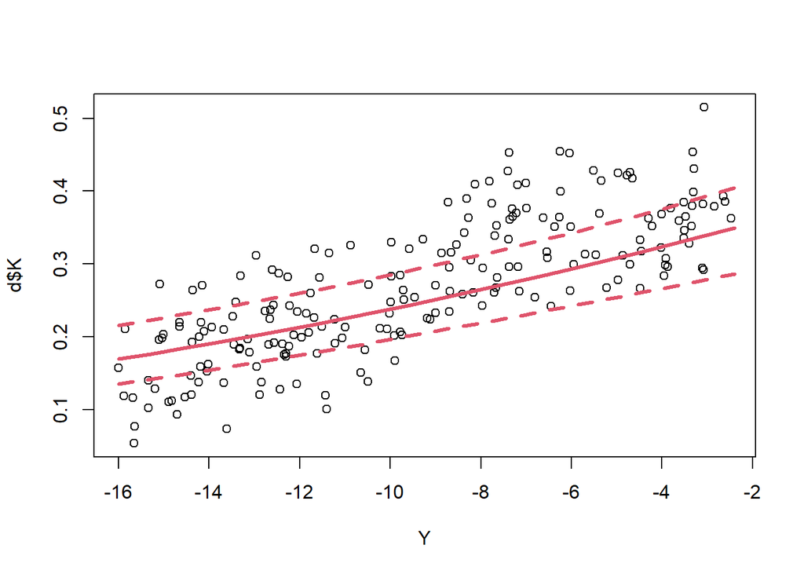

```r
plot(Y, d$K)
Yseq<-seq(-16, -2.4, len = 20)
KbyY<- sapply(Yseq,
    function (i) inv_logit(post$aK + t(t(post$bK_S) * d$S) + t(t(post$bK_SL) * colMeans(post$SL)) + post$bK_Y * i + rep(post$bK_dK,25) * d$K ))
PIs<- apply( KbyY , 2 , PI )
means<- apply( KbyY , 2 , mean )
lines(Yseq, means, col = 2, lwd = 3)
lines(Yseq, PIs[1, ], col = 2, lty = 2, lwd = 3)
lines(Yseq, PIs[2, ], col = 2, lty = 2, lwd = 3)
```

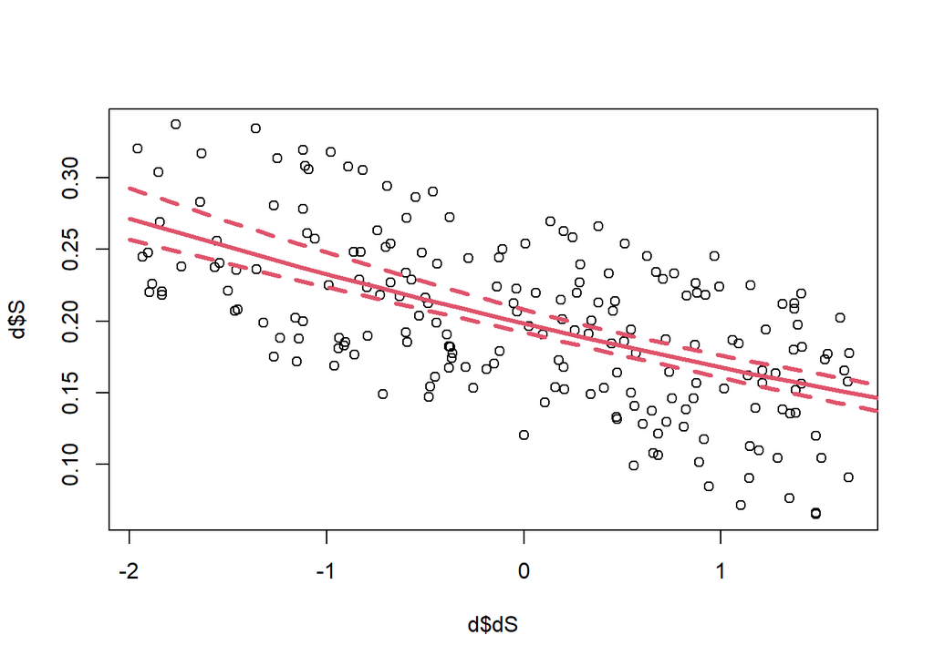

```r
# Model S
plot(d$dS, d$S)
dSseq<-seq(-2, 2, len = 20)
SbydS<- sapply(dSseq,
    function (i) inv_logit(post$aS + rep(post$bS_dS, 25) * i )) # Used mean of each simulated data
PIs<- apply( SbydS , 2 , PI )
means<- apply( SbydS , 2 , mean )
lines(dSseq, means, col = 2, lwd = 3)
lines(dSseq, PIs[1, ], col = 2, lty = 2, lwd = 3)
lines(dSseq, PIs[2, ], col = 2, lty = 2, lwd = 3)
```

```r
# Compare models
model_comparison <- compare(m1, m2)
print(model_comparison)
```

```
##         WAIC       SE    dWAIC      dSE    pWAIC       weight
## m1 -866.1677 18.34395  0.00000       NA 38.40909 1.000000e+00
## m2 -829.0077 14.55667 37.15998 14.54966 70.13781 8.527333e-09
```

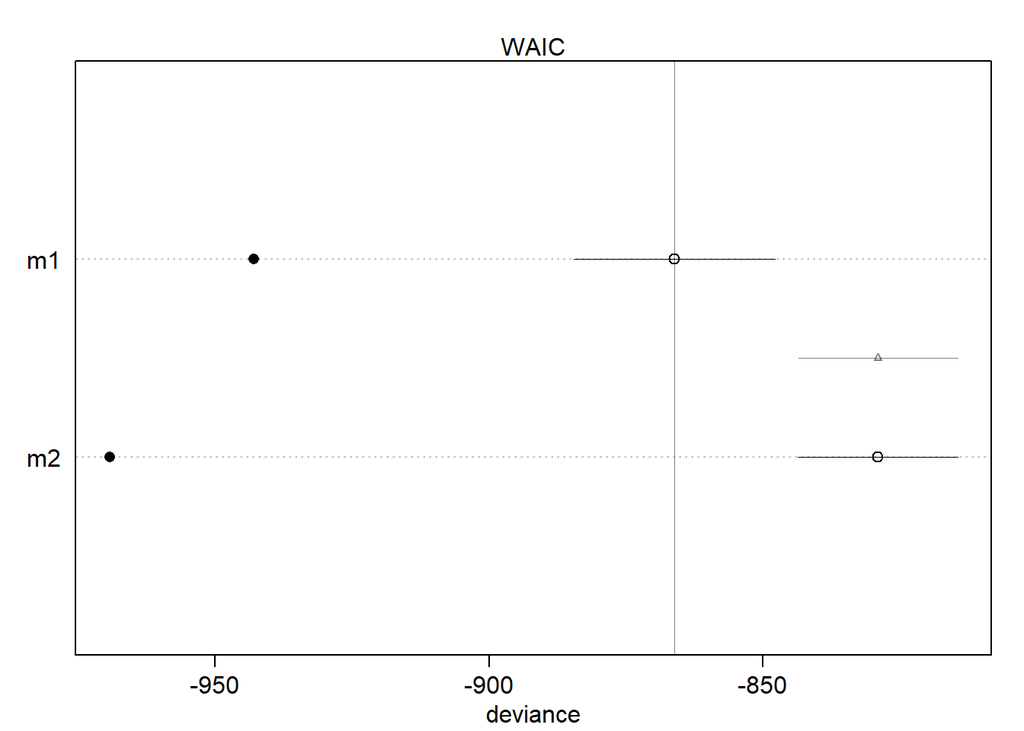

```r
# Plot WAIC/PSIS differences
plot(model_comparison)
```

### Key Columns in the compare Output:

- WAIC / PSIS: Lower values indicate better out-of-sample predictive accuracy.
- dWAIC / dPSIS: The difference in information criteria between the current model and the top-ranked (best) model.
- dSE: If the standard error is large relative to the difference, the two models have statistically indistinguishable predictive capacities.
- weight: The Akaike weight, which represents the relative probability or evidence that a given model will make the best predictions among the set of compared models

Therefore, the m1 is better than the other one.

# Model 3

```r
m3<- ulam(
    alist (
    # Main model K
        K ~ normal(mu_K, U),
        logit(mu_K) <- aK + bK_S * S + bK_SL * SL[i] + bK_Y * Y[i] + bK_dK * dK + bK_T[T],

        # We do not know anything about this but think similar for all group.
        # So use partial pooling to regularize the estimate.
        # mean should start at 0 and has small variation.

        c(aK, bK_S,  bK_SL, bK_Y, bK_dK) ~ normal(0,0.3),
        vector[25]: bK_T <- bK_T_bar + sigma_bK_T * z_bK_T[T],
        bK_T_bar ~ normal(0, 0.3), # regularization
        sigma_bK_T ~ exponential(6),
        z_bK_T[T] ~ normal(0, 1),

        U ~ exponential(1),

    # Model S
        S ~ normal(mu_S, sigma_S),
        logit(mu_S) <- aS + bS_dS * dS + bS_Y * Y[i] + bS_T[T],

        # I am hoping/believing b_dS is negative and b_Y_S is positive
        # partial pooling for the same reason for a2 and b_Y_S
        c(aS, bS_Y, bS_dS) ~ normal(0,0.1),
        vector[25]: bS_T <- bS_T_bar + sigma_bS_T * z_bS_T[T],
        bS_T_bar ~ normal(0, 0.001), # regularization
        sigma_bS_T ~ exponential(10),
        z_bS_T[T] ~ normal(0, 0.1),

        sigma_S ~ exponential(1),

        # Model SL by Y
        # The log function and prior was refered to the previous research of Sea Level Change over time.
        # This function is abstruct so I will have to actually stan code to provide accurate estimates
        # ulam code in r does not allow us to hartd code the conditional function.
        # vector[200]: SL ~ normal(muSL + aSL2, sigmaSL),
        vector[200]: SL ~ normal(mu_SL, sigma_SL),
        vector[200]: logit(mu_SL) <- aSL + Y[i] * bSL,
        aSL ~ normal(8, 0.01), # very low variation since this part is hard coded.
        bSL ~ normal(0.8, 0.01), # very low variation since this part is hard coded.

        sigma_SL ~ exponential(1),

         # Model T
        T ~ poisson((Y + 16)/ ( -2.4 + 16) * 25),

        # Model T by Y
        vector[200]:Y ~ uniform( -16 , -2.4 )

    ), dat = d, constraints = list(
        SL    = "lower=0,upper=1" # SL is between 0 and 1
    ),chains=4, cores=4, log_lik=TRUE
)
```

[output not shown]

[output not shown]

[output not shown]

[output not shown]

[output not shown]

[output not shown]

[output not shown]

[output not shown]

[output not shown]

```
## Chain 1
```

```
## Chain 2 Iteration:   1 / 1000 [  0%]  (Warmup)
```

[output not shown]

[output not shown]

[output not shown]

[output not shown]

```
## Chain 2
```

```
## Chain 3 Iteration:   1 / 1000 [  0%]  (Warmup)
```

[output not shown]

[output not shown]

[output not shown]

[output not shown]

```
## Chain 3
```

```
## Chain 4 Iteration:   1 / 1000 [  0%]  (Warmup)
```

[output not shown]

[output not shown]

[output not shown]

[output not shown]

```
## Chain 4
```

[output not shown]

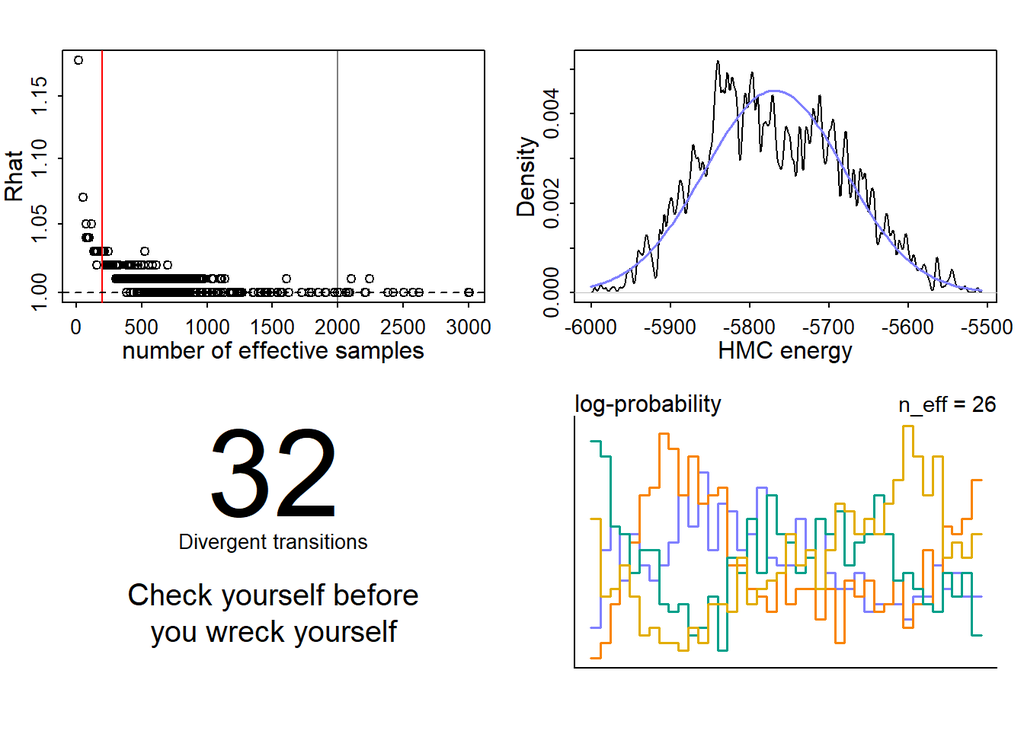

```r
dashboard(m3)
```

```r
precis(m3, depth=1)
```

```
## 450 vector or matrix parameters hidden. Use depth=2 to show them.
```

```
##                     mean           sd         5.5%        94.5%     rhat
## bK_dK      -2.680300e-01 0.0108031321 -0.285095606 -0.250647697 1.004450
## bK_Y        5.785987e-02 0.0114076974  0.039055744  0.075841634 1.017577
## bK_SL       4.583359e-01 0.1069330416  0.291612694  0.631258056 1.018434
## bK_S        7.431887e-01 0.2064349948  0.411008896  1.062660878 1.015089
## aK         -4.517283e-01 0.2299141020 -0.814887228 -0.086158479 1.000695
## bK_T_bar   -4.386037e-01 0.2232132904 -0.802636986 -0.084626969 1.007839
## sigma_bK_T  2.011134e-02 0.0143693799  0.001748388  0.045791468 1.008465
## U           2.491359e-02 0.0016868504  0.022318927  0.027670066 1.006724
## bS_dS      -2.888025e-01 0.0095825740 -0.304240958 -0.273730413 1.051845
## bS_Y        8.069574e-02 0.0029418842  0.076012652  0.085400694 1.054980
## aS         -6.639578e-01 0.0319918083 -0.714640188 -0.613921839 1.071301
## bS_T_bar   -6.754759e-05 0.0009713806 -0.001653049  0.001450405 1.002659
## sigma_bS_T  7.818048e-02 0.0684135957  0.005302071  0.210708573 1.014573
## sigma_S     9.983063e-03 0.0011684851  0.008157414  0.011905061 1.034014
## aSL         7.999380e+00 0.0098089235  7.984293541  8.015476126 1.001903
## bSL         8.051468e-01 0.0097046595  0.789532258  0.820269421 1.019619
## sigma_SL    2.764044e-03 0.0012852080  0.001330739  0.005356841 1.176231
##              ess_bulk
## bK_dK      1266.17317
## bK_Y        310.90039
## bK_SL       319.98127
## bK_S        517.48873
## aK         1200.64952
## bK_T_bar   1112.79526
## sigma_bK_T  340.47352
## U           669.65194
## bS_dS       116.91675
## bS_Y         75.58529
## aS           52.85026
## bS_T_bar   1909.46065
## sigma_bS_T  347.71633
## sigma_S     164.36864
## aSL        3003.27716
## bSL         255.54799
## sigma_SL     19.09780
```

-> Looks worse sampling efficiency.

# Posterior Check

```r
post <- extract.samples(m3)
```

- Again, I do not check the Hidden parameters since I have never touched it since m1

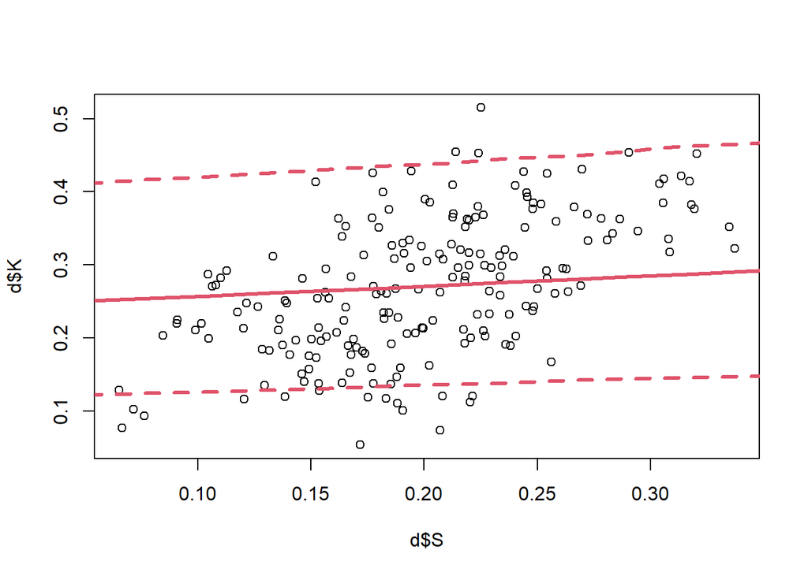

```r
# Model K

plot(d$S, d$K)
Sseq<-seq(0, 0.5, len = 20)
KbyS<- sapply(Sseq,
    function (i) inv_logit(post$aK + post$bK_S * i + post$bK_SL * colMeans(post$SL) + post$bK_Y * colMeans(post$Y)  + post$bK_dK * d$dK + colMeans(post$bK_T)[d$T] ))
means<- apply( KbyS , 2 , mean )
PIs<- apply( KbyS , 2 , PI )
lines(Sseq, means, col = 2, lwd = 3)
lines(Sseq, PIs[1, ], col = 2, lty = 2, lwd = 3)
lines(Sseq, PIs[2, ], col = 2, lty = 2, lwd = 3)
```

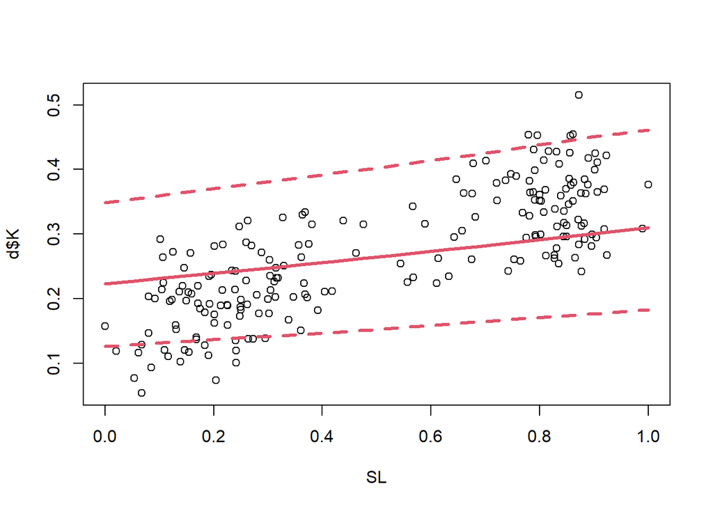

```r
plot(SL, d$K)
SLseq<-seq(0, 1, len = 20)
KbySL<- sapply(SLseq,  # This is tricky but use bK_T for T value and others are not stratified so randomly assigned
    function (i) inv_logit(post$aK + post$bK_S * d$S + post$bK_SL * i + post$bK_Y * colMeans(post$Y)  + post$bK_dK * d$dK + colMeans(post$bK_T)[d$T] ))
means<- apply( KbySL , 2 , mean )
PIs<- apply( KbySL , 2 , PI )
lines(SLseq, means, col = 2, lwd = 3)
lines(SLseq, PIs[1, ], col = 2, lty = 2, lwd = 3)
lines(SLseq, PIs[2, ], col = 2, lty = 2, lwd = 3)
```

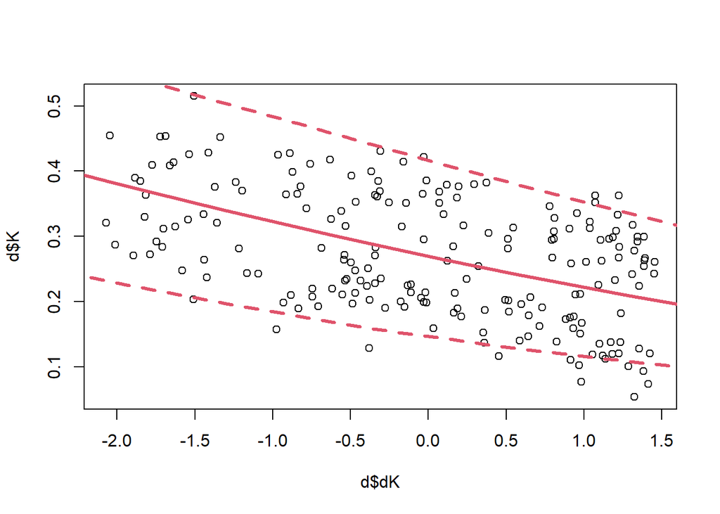

```r
plot(d$dK, d$K)
dKseq<-seq(-2.5, 2, len = 20)
KbydK<- sapply(dKseq,
    function (i) inv_logit(post$aK + post$bK_S * d$S + post$bK_SL * colMeans(post$SL) + post$bK_Y * colMeans(post$Y)  + post$bK_dK * i + colMeans(post$bK_T)[d$T] ))
PIs<- apply( KbydK , 2 , PI )
means<- apply( KbydK , 2 , mean )
lines(dKseq, means, col = 2, lwd = 3)
lines(dKseq, PIs[1, ], col = 2, lty = 2, lwd = 3)
lines(dKseq, PIs[2, ], col = 2, lty = 2, lwd = 3)
```

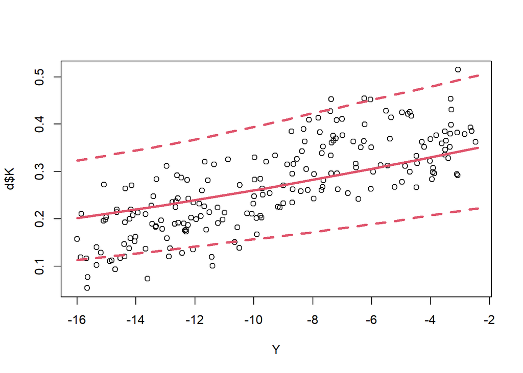

```r
plot(Y, d$K)
Yseq<-seq(-16, -2.4, len = 20)
KbyY<- sapply(Yseq,
    function (i) inv_logit(post$aK + post$bK_S * d$S + post$bK_SL * colMeans(post$SL) + post$bK_Y * i + post$bK_dK * d$dK + colMeans(post$bK_T)[d$T] ))
PIs<- apply( KbyY , 2 , PI )
means<- apply( KbyY , 2 , mean )
lines(Yseq, means, col = 2, lwd = 3)
lines(Yseq, PIs[1, ], col = 2, lty = 2, lwd = 3)
lines(Yseq, PIs[2, ], col = 2, lty = 2, lwd = 3)
```

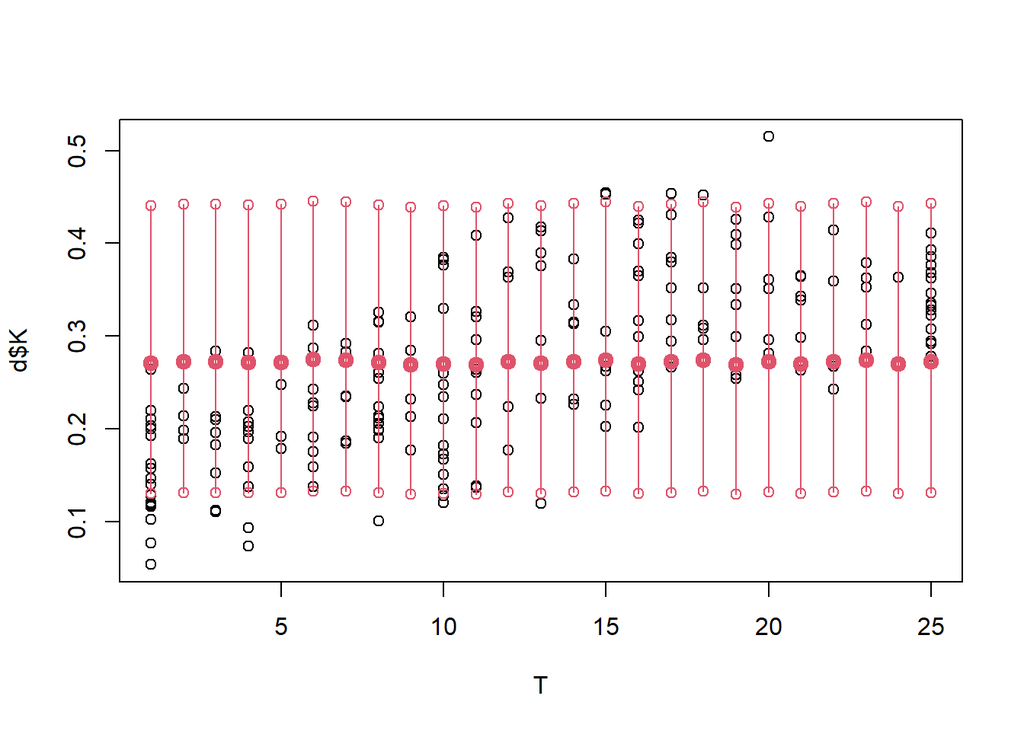

```r
plot(T, d$K)
KbyT<- sapply(1:25,
    function (i) inv_logit(post$aK + post$bK_S * d$S + post$bK_SL * colMeans(post$SL) + post$bK_Y * colMeans(post$Y) + post$bK_dK * d$dK + colMeans(post$bK_T)[i] ))
PIs<- apply( KbyT , 2 , PI )
means<- apply( KbyT , 2 , mean )
points(1:25, means, col = 2, lwd = 4)
points(1:25, PIs[1, ], col = 2, lty = 2 )
points(1:25, PIs[2, ], col = 2, lty = 2 )
for(i in 1:25) lines(c(i,i), c(PIs[1, i], PIs[2, i]), col = 2)
```

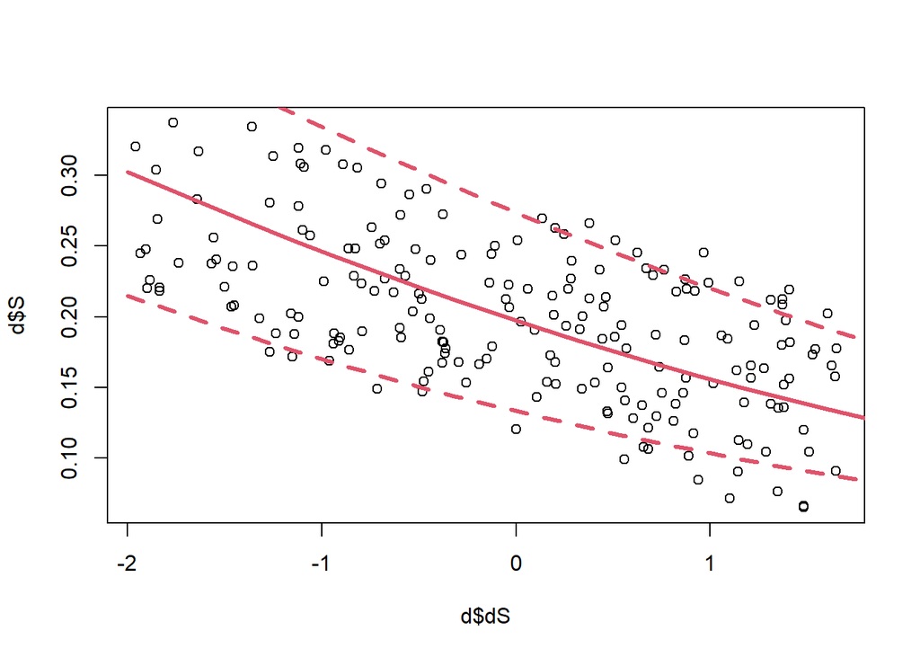

```r
# Model S

plot(d$dS, d$S)
dSseq<-seq(-2, 2, len = 20)
SbydS<- sapply(dSseq,
    function (i) inv_logit(post$aS + post$bS_dS * i + post$bS_Y * colMeans(post$Y) + colMeans(post$bS_T)[d$T]))
means<- apply( SbydS , 2 , mean )
PIs<- apply( SbydS , 2 , PI )
lines(dSseq, means, col = 2, lwd = 3)
lines(dSseq, PIs[1, ], col = 2, lty = 2, lwd = 3)
lines(dSseq, PIs[2, ], col = 2, lty = 2, lwd = 3)
```

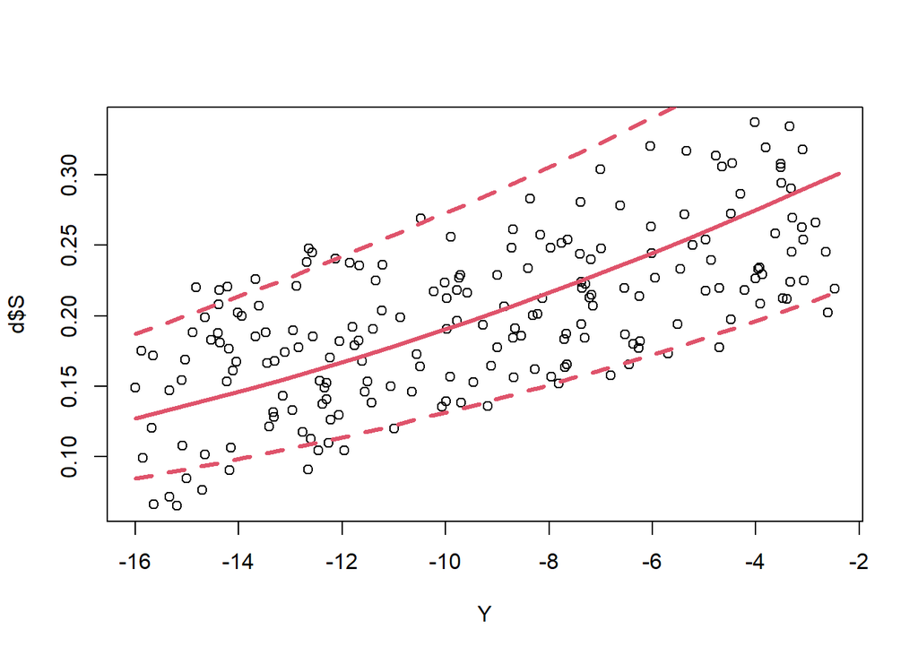

```r
plot(Y, d$S)
Yseq<-seq(-16, -2.4, len = 20)
SbyY<- sapply(Yseq,
    function (i) inv_logit(post$aS + post$bS_dS * d$dS + post$bS_Y * i + colMeans(post$bS_T)[d$T]))
means<- apply( SbyY , 2 , mean )
PIs<- apply( SbyY , 2 , PI )
lines(Yseq, means, col = 2, lwd = 3)
lines(Yseq, PIs[1, ], col = 2, lty = 2, lwd = 3)
lines(Yseq, PIs[2, ], col = 2, lty = 2, lwd = 3)
```

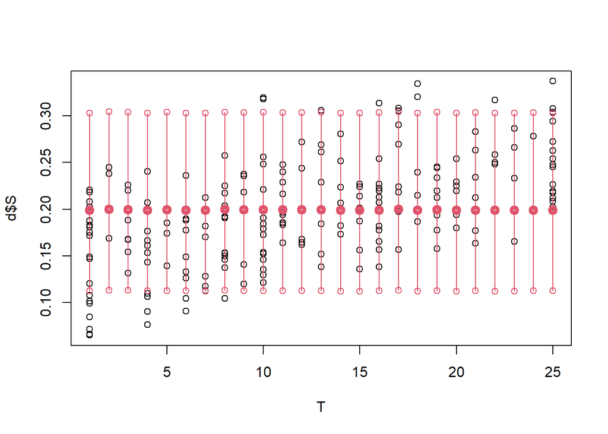

```r
plot(T, d$S)
SbyT<- sapply(1:25,
    function (i) inv_logit(post$aS + post$bS_dS * d$dS + post$bS_Y * colMeans(post$Y) + colMeans(post$bS_T)[i]))
PIs<- apply( SbyT , 2 , PI )
means<- apply( SbyT , 2 , mean )
points(1:25, means, col = 2, lwd = 4)
points(1:25, PIs[1, ], col = 2, lty = 2)
points(1:25, PIs[2, ], col = 2, lty = 2)
for(i in 1:25) lines(c(i,i), c(PIs[1, i], PIs[2, i]), col = 2)
```

```r
# Compare models
model_comparison <- compare(m1, m3)
print(model_comparison)
```

```
##         WAIC       SE    dWAIC      dSE    pWAIC    weight
## m1 -866.1677 18.34395 0.000000       NA 38.40909 0.6149165
## m3 -865.2316 18.59327 0.936053 2.012585 38.37206 0.3850835
```

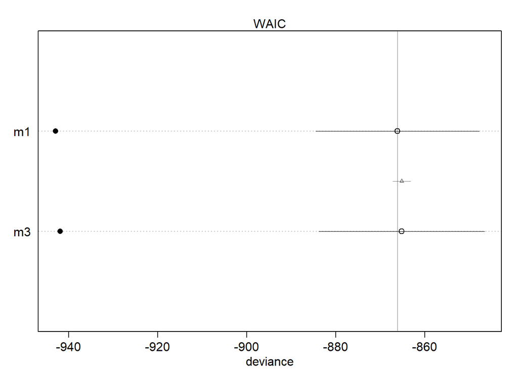

```r
# Plot WAIC/PSIS differences
plot(model_comparison)
```

```r
model_comparison <- compare(m2, m3)
print(model_comparison)
```

```
##         WAIC       SE    dWAIC      dSE    pWAIC       weight
## m3 -865.2316 18.59327  0.00000       NA 38.37206 1.000000e+00
## m2 -829.0077 14.55667 36.22393 14.39358 70.13781 1.361678e-08
```

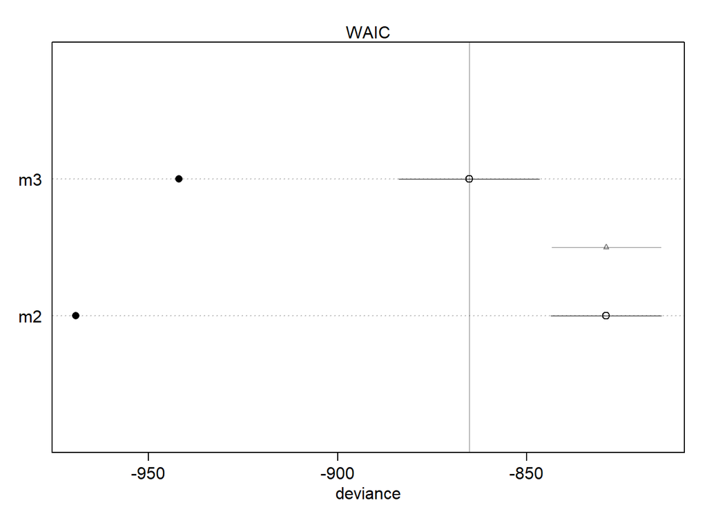

```r
# Plot WAIC/PSIS differences
plot(model_comparison)
```

# Future Suggestions

- Removing causal relationship in each model (for example, no causal relationship from Y to K) may be examined with actual data.
- The Model 3 still has a problem of bK_T and bS_T as they do not fit the data. I am trying to understand the reason and fix it.

```r
rm(list=ls())
```